# Baysian Statistics the Fun Way - Will Kurt

Michael Freeze

4/27/2022

```r
library(magrittr)
library(ggplot2)
```

# Binomial Distribution Notes and Exercises

Based on Bayesian Statistics the Fun Way by Will Kurt

### Structure of a Binomial Distribution

The distribution you’ll learn about here is the binomial distribution, used to calculate the probability of a certain number of successful outcomes, given a number of trials and the probability of the successful outcome.

Example problems that follow a binomial distribution include the probability of:

- Flipping two heads in three coin tosses
- Buying 1 million lottery tickets and winning at least once
- Rolling fewer than three 20s in 10 rolls of a 20-sided die

Each of these problems shares a similar structure. Indeed, all binomial distributions involve three *parameters*:

- $k$ the number of outcomes we care about (Successes)
- $n$ the total number of trials
- $p$ the probability of the event happening

The shorthand notation to express this distribution looks like this" $B(k;n,p)$

For the example of the three coin tosses, we would write $B(2; 3,\frac{1}{2})$. Notice that the $k$ is separated from the other parameters by a semicolon. This is because when we are talking about a distribution of values, we usually care about all values of $k$ for a fixed $n$ and $p$. So, $B(k;n,p)$ denotes each value in our distribution, but the entire distribution is usually referred to by simply $B(n,p)$

### Combinatorics: Advanced Counting with the Binomial Coefficient

There is a special operation in combinatorics, called the *binomial coefficient*, that represents counting the number of ways we can select $k$ from $n$ - that is, selecting the outcomes we care about from the total number of trials. The notation for the binomial coefficient looks like this:

$\binom{n}{k}$

We read that expression as “$n$ choose $k$”. So, for our example, we would represent “in three tosses choose two heads” as:

$\binom{3}{2}$

The definition of this operation is:

$\binom{n}{k} = \frac{n!}{k!(n-k)!}$

The $!$ means *factorial*, which is the product of all the numbers up to and including the number before the $!$ symbol, so $3! = (3 * 2 * 1)$

Most mathematical programming languages indicate the binomial coefficient using the `choose()` function. For example, with the mathematical language R, we would compute the binomial coefficient for the case of flipping two heads in three tosses with the following call:

```r
choose(3,2)
```

```
## [1] 3
```

### Calculating the Probability of the Desired Outcome

Let’s look at the probability of getting two heads in five coin tosses

For $B(2; 5, \frac{1}{2})$, we would say $\binom{5}{2}\frac{1}{2}^{2}(1-\frac{1}{2})^{3}$

Generalizing this formula results in:

$B(k;n, p)$ = $\binom{n}{k}p^{k}(1-p)^{n-k}$

So, Using this generalization, we could calculate the probability of flipping $k$ heads in $n$ flips of a coin.

For example, the probability of flipping 12 heads in 24 coin tosses would be:

$B(12;24, \frac{1}{2})$ = $\binom{24}{12}\frac{1}{2}^{12}(1-\frac{1}{2})^{12}$

This formula, which is the basis of the binomial distribution, is called the *Probability Mass Function*. The *mass* part of the name comes from the fact that we can use it to calculate the amount of probability for *any* given $k$ using a *fixed* $n$ and $p$, so this is the mass of our probability.

For example, we can plug all the possible values for $k$ in 10 coin tosses into our PMF and visualize what the binomial distribution looks like for all possible values, like so:

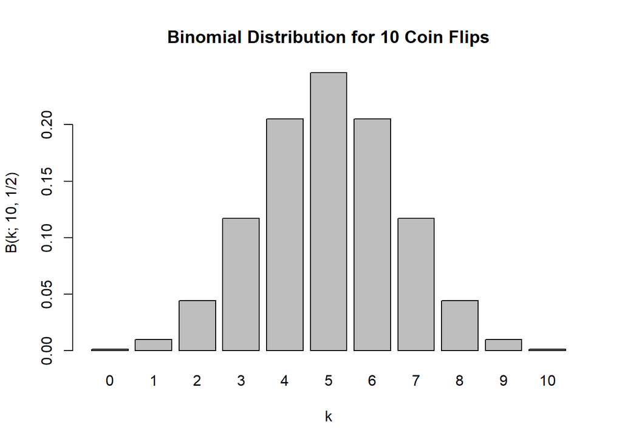

```r
dbinom(seq(from = 0, to = 10,  by = 1), 10, .5) %>%
  barplot(names.arg = c(0,1,2,3,4,5,6,7,8,9,10),
          xlab = 'k',
          ylab = 'B(k; 10, 1/2)',
          main = 'Binomial Distribution for 10 Coin Flips')
```

We can do the same thing for the probability of getting a 6 when rolling a six sided die 10 times

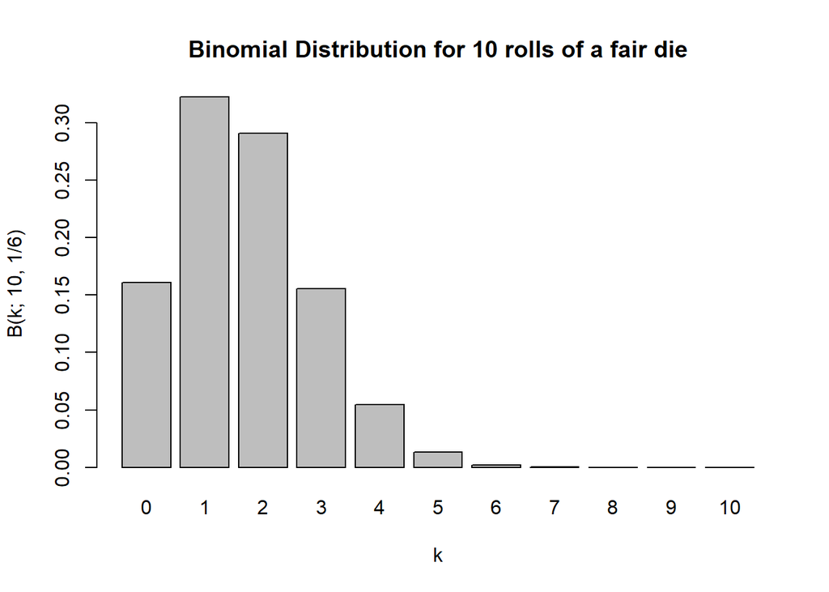

```r
dbinom(seq(from = 0, to = 10,  by = 1), 10, .167) %>%
  barplot(names.arg = c(0,1,2,3,4,5,6,7,8,9,10),
          xlab = 'k',
          ylab = 'B(k; 10, 1/6)',
          main = 'Binomial Distribution for 10 rolls of a fair die')
```

### Example: Gacha Games

Gacha games are a genre of mobile games, particularly popular in Japan, in which players are able to purchase virtual cards with in-game currency. The catch is that all cards are given at random, o when players purchase cards they can’t choose which ones they receive. Since not all cards are equally desirable, players are encouraged to keep pulling cards from the stack until they hit the one they want, in a fashion similar to a slot machine. We’ll see how the binomial distribution can help us to decide to take a particular risk in an imaginary Gacha game.

Here’s the scenario. You have a new game called Bayesian Battlers. The current set of cards you can pull from is called a banner. The banner contains some average cards and some featured cards that are more valuable. As you may suspect all of th ecards in Bayesian Battlers are famous probabilists and statisticians. The top cards in this banner are as follows, each with its respective probability of being pulled:

- Thomas Bayes: 0.721%
- E.T. Jaynes: 0.720%
- Harold Jeffreys: 0.718%
- Andrew Gelman: 0.718%
- John Kruschke: 0.714%

These featured cards account for only .03591 of the total probability. Since probability must sum to 1, the chance of pulling the less desirable cards is the other 0.96409. Additionally, we treat the pile of cards that we pull from as effectively infinite, meaning that pulling a specific card does not change the probability of getting any other card - the card you pull here does not then disappear from the pile. This is different than if you were to pull a physical card from a single deck of cards without shuffling the card back in.

You really want the E.T.Jaynes card to complete your elite Bayesian team.  
Unfortunately, you have to purchase the in-game currency, Bayes Bucks, in order to pull cards. It costs one Bayes Buck to pull one card, but there’s a special on right now allowing you to purchase 100 bayes bucks from only $10. That’s the maximum you’re willing to spend on this game, and *only* if the probability of getting that awesome E.T. Jaynes card is greater than or equal to 0.5.

Of course, we can plug our probability of getting the E.T.Jaynes card into our formula for the binomial distribution to see what we would get:

```r
dbinom(1, 100, .00721)
```

```
## [1] 0.3522226
```

Our result is less than 0.5 so we should give up. But wait, we forgot something very important. In the preceding formula we calculated only the probability of getting *exactly one* E.T.Jaynes card. But what if we pulled two or three or more? What we really want to know is the probability of getting *at least* or, said differently, *one or more*. We could writet this out as:

$\binom{100}{1}0.00271^{1}(1-0.00721)^{99} + \binom{100}{2}0.00271^{2}(1-0.00721)^{98} + \binom{100}{3}0.00271^{3}(1-0.00721)^{97} ...$

and so on, for the 100 cards you can pull with your Bayes Bucks. But, this gets really tedious. So, instead, we use the special mathematical notion $\Sigma$:

$\sum_{x = k}^{n}\binom{n}{k}p^{k}(1-p)^{n-k}$

or, for our situation:

$\sum_{x = k}^{100}\binom{100}{k}0.00721^{k}(1-0.00721)^{100-k}$

We’ve made the problem simpler but, rather than pulling out a calculator, we will use `pbinom()` to automatically sum up all these values for $k$ in our PMF.

`pbinom()` takes three required arguments $(k,n,p)$ and an optional fourth argument called `lower.tail` (which defaults to `TRUE`). When the fourth argument is `TRUE`, it sums up the all of the probabilities less than or equal to the first argument. When `lower.tail` is `FALSE` it sums up the probabilities greater than our $k$. Consider the following example:

If we wanted to know the probability of pulling at least one E.T. Jaynes card, we would use

```r
pbinom(0, 100, .00720, lower.tail = FALSE)
```

```
## [1] 0.5145138
```

So, even though the probability of getting exactly one E.T. Jaynes card is only 0.352 (35%), the probability of pulling at least one is is high enough to risk it.

## Book Exercises

### Question 1

What are the parameters of the binomial distribution for the probability of rolling either a 1 or a 20 on a 20-sided die, if we roll the die 12 times?

### Question 2

There are four aces in a deck of 52 cards. If you pull a card, return the card, then reshuffle and pull a card again, how many ways can you pull just one ace in five pulls?

### Question 3

For the example in Question 2, what is the probability of pulling five aces in 10 pulls (remember that the card is shuffled back into the deck when it is pulled)?

## Book Answers

### Answer 1

$B(1; 12, \frac{1}{10})$

### Answer 2

We could say $\binom{n}{k}$ or calculate it using:

```r
choose(5, 1)
```

```
## [1] 5
```

### Answer 3

There are four aces in a deck of 52 cards and $\frac{4}{52} = \frac{1}{13}$

For $B(5; 10, \frac{1}{13})$, we would say: $\binom{10}{5}\frac{1}{13}^{5}(1-\frac{1}{13})^{5}$

and calculated with

```r
dbinom(5, 10, 0.07692308)
```

```
## [1] 0.0004548554
```